# ISLR Chapter 7 Exercises

I start with a single iteration. Estiamte the $\beta_2$ by subtracting the product of $\beta_1$ and its predictor from the response and conducting regression. Then use this estimate to estiamte $\beta_1$, and repeat.

```r
X1 <- rnorm(100)
X2 <- X1 + rnorm(100)
Y <- 6*X1 + -10*X2 + rnorm(100)

beta1 <- 5

a <- Y - beta1*X1
beta2 <- lm(a~X2)$coef[2]

a <- Y - beta2*X2
beta1 <- lm(a~X1)$coef[2]
beta0 <- lm(a~X1)$coef[1]
beta0
```

```
## (Intercept)
##  -0.2240398
```

```r
beta1
```

```
##       X1
## 5.415128
```

```r
beta2
```

```
##        X2
## -9.492691
```

Now we iterate. I abuse deep assign when writing the function. Remarkably, the estimates converge after just 10 iterations.

```r
estimates <- map_dfr(1:1000, function(.x){
  a <- Y - beta1*X1
  beta2 <<- lm(a~X2)$coef[2]

  a <- Y - beta2*X2
  beta1 <<- lm(a~X1)$coef[2]
  beta0 <<- lm(a~X1)$coef[1]
  data.frame(iteration = .x, beta0 = beta0, beta1 = beta1, beta2 = beta2)
})

ref <- lm(Y ~ X1 +X2)
coef(ref)
```

```
## (Intercept)          X1          X2
##   -0.111618    5.983205  -10.043870
```

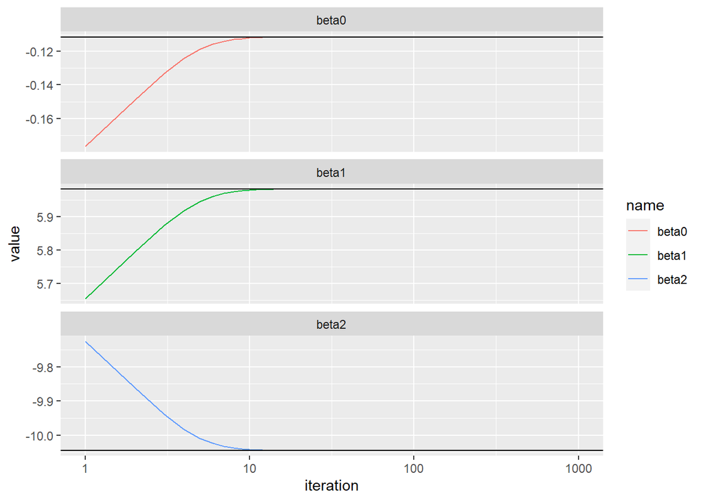

```r
estimates %>% pivot_longer(starts_with("beta")) %>%
  mutate(actual = case_when(name =="beta0" ~ coef(ref)[1],
                            name == "beta1" ~coef(ref)[2],
                            TRUE ~ coef(ref)[3])) %>%
  ggplot(aes(x = iteration, y = value, col = name)) +
  geom_line()+
  geom_hline(aes(yintercept = actual)) +
  scale_x_log10()+
  facet_wrap( name ~ ., ncol = 1, scales = "free_y")
```

The final problem asks us to apply backfitting to a $p=100$ dataset. Remarkably, the backfit estimate is much closer than a multivariate model,a and converges after just two iterations!

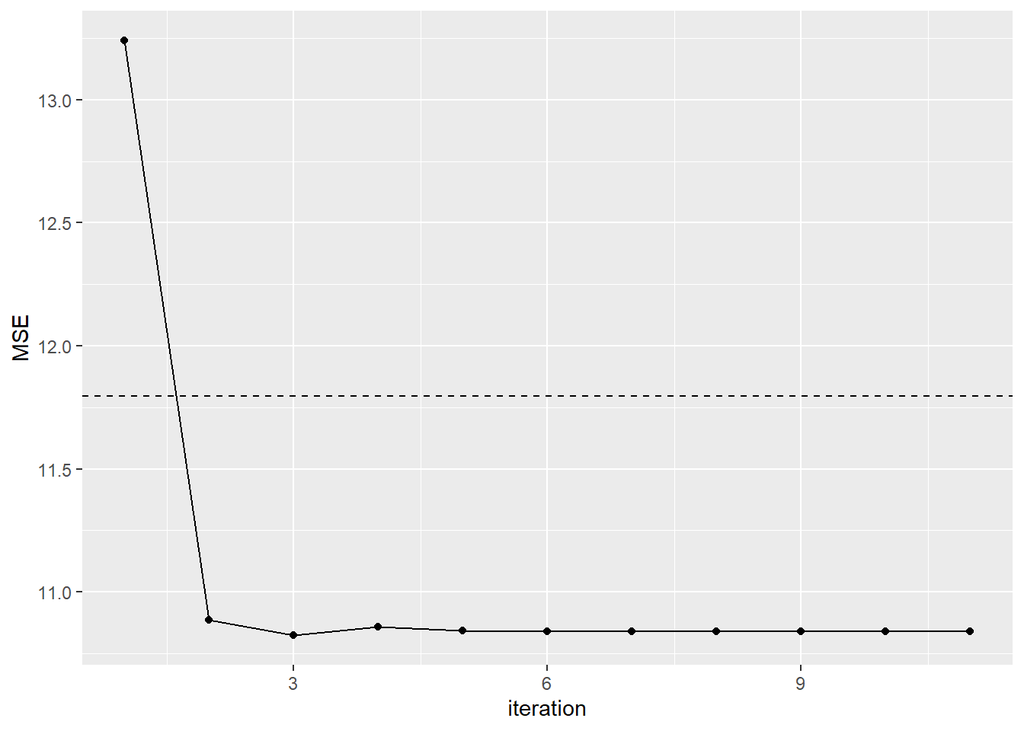

```r
xes <- sample(1:10, 100, replace = TRUE)
actual <- sample(0:10, 100, replace = TRUE)
dat <- replicate(100, rnorm(1000)) %>%
  as.data.frame() *xes

Y <- (dat * actual) %>% reduce(`+`)

backfit <- function(res = rep(1, 100), place = 1){

  # compute partial residual
  pr <- Y - ((dat[,-place]  * res[-place])) %>%
    reduce(`+`)

  #Fit model on PRs, take beta
  res[place] <- coef(lm(pr~dat[,place]))[2]
  place = place +1

  #Exit at vector end
  if(place > length(res)){

    return(res)
  }
  backfit(res = res, place = place)
  #res
}
backfits <- replicate(10, backfit) %>%
  purrr::accumulate(~exec(.y, .x), .init = backfit()) %>%
  map(~(actual - .x)^2) %>%
  map_dbl(mean)

ref <- mean((actual -(coef(lm(Y~., data = dat))[-1]))^2)
tibble(MSE = backfits, iteration = seq_along(backfits)) %>%
  ggplot(aes(x = iteration, y = MSE)) +
  geom_line() +
  geom_point() +
  geom_hline(linetype = "dashed", yintercept = ref)
```